# 4. Writing Functions in R

Timo Meiendresch

```r
library(purrr)
```

# Functions in R

Recall the elements of a function in R:

- formals
- body
- environment

```r
# typical function definition
add <- function(x, y=1){
  x+y
}

#
args(add)
```

```
## function (x, y = 1)
## NULL
```

```r
formals(add)
```

```
## $x
##
##
## $y
## [1] 1
```

```r
body(add)
```

```
## {
##     x + y
## }
```

```r
environment(add)
```

```
## <environment: 0x00000000131c5d70>
```

- Last expression evaluated in a function is the return value
- `return(value)` forces the function to stop execution and return value
- anonymous functions: functions without a name

```r
# anonymous function
(function(x){x+1})(2)
```

```
## [1] 3
```

Three parts of a function:

- arguments
- body
- environment

### Environments

Scoping describes how R looks up values by name. If a name isn’t defined inside a function, R will look one level up.

```r
x <- 2
g <- function(){
  y <- 1
  c(x,y)
}

g()
```

```
## [1] 2 1
```

```r
#
```

Scoping describes where, not when, to look for a value

```r
# depends on environment
f <- function() x
x <- 15
f()
```

```
## [1] 15
```

```r
# x in env is change
x <- 20
f()
```

```
## [1] 20
```

- When you call a function, a new environment is made for the function to do its work.
- New env is populated with the argument values
- Objects are looked for first in this environment

### Data Structures

```r
typeof(letters)
```

```
## [1] "character"
```

```r
typeof(1:10)
```

```
## [1] "integer"
```

```r
typeof(NULL)
```

```
## [1] "NULL"
```

```r
length(NULL)
```

```
## [1] 0
```

```r
typeof(NA)
```

```
## [1] "logical"
```

```r
length(NA)
```

```
## [1] 1
```

- Missing values are contagious!

Lists:

- Useful because they can contain heterogeneous objects
- complicated return objects are lists, ie from lm()

### for loops

Parts of a for loop

- sequence
- body

```r
# looping over cols in a df
df <- data.frame(
  a = rnorm(10),
  b = rnorm(10),
  c = rnorm(10),
  d = rnorm(10)
)

for (i in 1:ncol(df)) {
  print(median(df[[i]]))
}
```

```
## [1] 0.2183076
## [1] 0.5441977
## [1] 0.2364744
## [1] -0.6558017
```

Moving forward, we’ll see a safer way to generate the sequence using `seq_along()` and saving the output instead of printing it.

```r
# Replace the 1:ncol(df) sequence
for (i in seq_along(df)) {
  print(median(df[[i]]))
}
```

```
## [1] 0.2183076
## [1] 0.5441977
## [1] 0.2364744
## [1] -0.6558017
```

```r
# Create an empty data frame
empty_df <- data.frame()

# Repeat for loop to verify there is no error
for (i in seq_along(empty_df)) {
  print(median(empty_df[[i]]))
}

# Create new double vector: output
output <- vector(mode = "double", ncol(df))

# Alter the loop
for (i in seq_along(df)) {
  # Change code to store result in output
  output[[i]] <- median(df[[i]])
}

# Print output
print(output)
```

```
## [1]  0.2183076  0.5441977  0.2364744 -0.6558017
```

# When and how you should write a function

### When?

- Copy-paste rule of thumb: Whenever you have copied-and-pasted twice, it’s time to write a function

```r
# Define example vector x
x <- c(1:10, NA)

# Define rng
rng <- range(x, na.rm=TRUE)

# Rewrite this snippet to refer to the elements of rng
(x - min(x, na.rm = TRUE)) /
  (rng[2] - rng[1])
```

```
##  [1] 0.0000000 0.1111111 0.2222222 0.3333333 0.4444444 0.5555556 0.6666667
##  [8] 0.7777778 0.8888889 1.0000000        NA
```

```r
# Use this in function
rescale01 <- function(x) {
  rng <- range(x, na.rm=TRUE)
  (x - rng[1]) / (rng[2] - rng[1])
}

# Test your function, call rescale01 using the vector x as the argument
rescale01(x)
```

```
##  [1] 0.0000000 0.1111111 0.2222222 0.3333333 0.4444444 0.5555556 0.6666667
##  [8] 0.7777778 0.8888889 1.0000000        NA
```

### How?

1. Start with a simple problem. It is helpful if you know the answer.
2. Get a working snipped of code.
3. Rewrite to use temporary variables. Rewrite for clarity. Snippet is the body of the function. Temporary arguments are then the inputs
4. Turn into a function

```r
# Define example vectors x and y
x <- c( 1, 2, NA, 3, NA)
y <- c(NA, 3, NA, 3,  4)

# Count how many elements are missing in both x and y
sum(is.na(x) & is.na(y))
```

```
## [1] 1
```

```r
# Turn this snippet into a function: both_na()
both_na <- function(x,y){
  sum(is.na(x) & is.na(y))
}
```

Note that this function only works in cases where x and y have the same length.

### How to write a good function?

Function is

- correct
- understandable
- readable for humans and computers
- correct + understandable = obviously correct

Naming the function as a verb which describes what it does is a good start. In addition, we should not use function names that are already taken nor use variables which have already a meaning (e.g. `T` or `c`).

```r
# Altered mean_ci function
mean_ci <- function(x, level = 0.95) {
  if (length(x) == 0) {
    warning("`x` was empty",
    interval <- c(-Inf, Inf))
    return(interval)
  } else {
    se <- sd(x) / sqrt(length(x))
    alpha <- 1 - level
    mean(x) + se * qnorm(c(alpha / 2, 1 - alpha / 2))
  }
}

mean_ci(numeric(0))
```

```
## [1] -Inf  Inf
```

```r
mean_ci(x)
```

```
## [1] NA NA
```

```r
# replace_missings function
replace_missings <- function(x, replacement) {
  x[is.na(x)] <- replacement
  cat(sum(is.na(x)), replacement, "\n")
  x
}

replace_missings(x, 0)
```

```
## 0 0
```

```
## [1] 1 2 0 3 0
```

```r
# A few more tweaks...
replace_missings <- function(x, replacement) {
  is_miss <- is.na(x)
  x[is_miss] <- replacement

  # Rewrite to use message()
  message(sum(is_miss), " missings replaced by the value ", replacement)
  x
}

replace_missings(x, replacement=10)
```

```
## 2 missings replaced by the value 10
```

```
## [1]  1  2 10  3 10
```

# Functional Programming

- Alternatives to the for-loop.
1. Rely on domain knowledge
2. Use variables
3. Extract out common code

```r
# Initialize output vector
output <- numeric(ncol(df))

for (i in seq_along(df)){
  output[i] <- median(df[[i]])
}

# turn this code into col_median()
col_median <- function(df){
  output <- numeric(ncol(df))
  for (i in seq_along(df)){
    output[[i]] <- median(df[[i]])
  }
  output
}

col_median(df)
```

```
## [1]  0.2183076  0.5441977  0.2364744 -0.6558017
```

```r
# change to col_mean()
col_mean <- function(df) {
  output <- numeric(ncol(df))
  for (i in seq_along(df)) {
    output[[i]] <- mean(df[[i]])
  }
  output
}

# Define col_sd() function
col_sd <- function(df) {
  output <- numeric(length(df))
  for (i in seq_along(df)) {
    output[[i]] <- sd(df[[i]])
  }
  output
}
```

We just copied and paste the function `col_median` two times! This is a sign that we need to write a function! We start with a simple example first…

```r
# Add a second argument called power
f <- function(x, power) {
    # Edit the body to return absolute deviations raised to power
    (abs(x - mean(x)))^power
}
```

Note that functions can be arguments too!

```r
# col_sumamry function
col_summary <- function(df, fun){
  output <- numeric(length(df))
  for (i in seq_along(df)){
    output[i] <- fun(df[[i]])
  }
  output
}

col_summary(df, fun = median)
```

```
## [1]  0.2183076  0.5441977  0.2364744 -0.6558017
```

```r
col_summary(df, fun = mean)
```

```
## [1]  0.31546401  0.55401450  0.03823683 -0.82738938
```

```r
col_summary(df, fun = sd)
```

```
## [1] 0.9731663 0.7970204 0.8387938 0.9860739
```

```r
# Find the column IQRs using col_summary()
col_summary(df, fun = IQR)
```

```
## [1] 1.7331589 0.8633259 0.8212769 1.1044192
```

### Introducing purrr

Passing functions as arguments is a principle that we’ve already seen with the apply family functions. Now, we want to introduce into a whole family of functions with similar workings. The `map()` functions in the `purrr` package.

Every map functions works the same way:

```r
map_dbl(.x, .f, ...)
```

1. Loop over a vector .x
2. Do something to each element .f
3. Return the results

There is one function for each type of vector:

- `map()` returns a list
- `map_dbl()` returns a double vector
- `map_lgl()` returns a logical vector
- `map_int()` returns a integer vector
- `map_chr()` returns a character vector

Now, let’s use `map_dbl()` like we have used our summary function before:

```r
# Use map_dbl() to find column means
map_dbl(df, mean)
```

```
##           a           b           c           d
##  0.31546401  0.55401450  0.03823683 -0.82738938
```

```r
# Use map_dbl() to column medians
map_dbl(df, median)
```

```
##          a          b          c          d
##  0.2183076  0.5441977  0.2364744 -0.6558017
```

```r
# Use map_dbl() to find column standard deviations
map_dbl(df, sd)
```

```
##         a         b         c         d
## 0.9731663 0.7970204 0.8387938 0.9860739
```

Check the type of an individual output (e.g. of a dataframe) to determine which `map_` funciton is appropriate.

### Shortcuts for specifying .f

- Using `~`to define an anonymous function on the fly

Data that will be used are a subset of the `mtcars` data.

```r
cyl <- split(mtcars, mtcars$cyl)
str(cyl)
```

```
## List of 3
##  $ 4:'data.frame':   11 obs. of  11 variables:
##   ..$ mpg : num [1:11] 22.8 24.4 22.8 32.4 30.4 33.9 21.5 27.3 26 30.4 ...
##   ..$ cyl : num [1:11] 4 4 4 4 4 4 4 4 4 4 ...
##   ..$ disp: num [1:11] 108 146.7 140.8 78.7 75.7 ...
##   ..$ hp  : num [1:11] 93 62 95 66 52 65 97 66 91 113 ...
##   ..$ drat: num [1:11] 3.85 3.69 3.92 4.08 4.93 4.22 3.7 4.08 4.43 3.77 ...
##   ..$ wt  : num [1:11] 2.32 3.19 3.15 2.2 1.61 ...
##   ..$ qsec: num [1:11] 18.6 20 22.9 19.5 18.5 ...
##   ..$ vs  : num [1:11] 1 1 1 1 1 1 1 1 0 1 ...
##   ..$ am  : num [1:11] 1 0 0 1 1 1 0 1 1 1 ...
##   ..$ gear: num [1:11] 4 4 4 4 4 4 3 4 5 5 ...
##   ..$ carb: num [1:11] 1 2 2 1 2 1 1 1 2 2 ...
##  $ 6:'data.frame':   7 obs. of  11 variables:
##   ..$ mpg : num [1:7] 21 21 21.4 18.1 19.2 17.8 19.7
##   ..$ cyl : num [1:7] 6 6 6 6 6 6 6
##   ..$ disp: num [1:7] 160 160 258 225 168 ...
##   ..$ hp  : num [1:7] 110 110 110 105 123 123 175
##   ..$ drat: num [1:7] 3.9 3.9 3.08 2.76 3.92 3.92 3.62
##   ..$ wt  : num [1:7] 2.62 2.88 3.21 3.46 3.44 ...
##   ..$ qsec: num [1:7] 16.5 17 19.4 20.2 18.3 ...
##   ..$ vs  : num [1:7] 0 0 1 1 1 1 0
##   ..$ am  : num [1:7] 1 1 0 0 0 0 1
##   ..$ gear: num [1:7] 4 4 3 3 4 4 5
##   ..$ carb: num [1:7] 4 4 1 1 4 4 6
##  $ 8:'data.frame':   14 obs. of  11 variables:
##   ..$ mpg : num [1:14] 18.7 14.3 16.4 17.3 15.2 10.4 10.4 14.7 15.5 15.2 ...
##   ..$ cyl : num [1:14] 8 8 8 8 8 8 8 8 8 8 ...
##   ..$ disp: num [1:14] 360 360 276 276 276 ...
##   ..$ hp  : num [1:14] 175 245 180 180 180 205 215 230 150 150 ...
##   ..$ drat: num [1:14] 3.15 3.21 3.07 3.07 3.07 2.93 3 3.23 2.76 3.15 ...
##   ..$ wt  : num [1:14] 3.44 3.57 4.07 3.73 3.78 ...
##   ..$ qsec: num [1:14] 17 15.8 17.4 17.6 18 ...
##   ..$ vs  : num [1:14] 0 0 0 0 0 0 0 0 0 0 ...
##   ..$ am  : num [1:14] 0 0 0 0 0 0 0 0 0 0 ...
##   ..$ gear: num [1:14] 3 3 3 3 3 3 3 3 3 3 ...
##   ..$ carb: num [1:14] 2 4 3 3 3 4 4 4 2 2 ...
```

```r
head(cyl[[1]])
```

```
##                 mpg cyl  disp hp drat    wt  qsec vs am gear carb
## Datsun 710     22.8   4 108.0 93 3.85 2.320 18.61  1  1    4    1
## Merc 240D      24.4   4 146.7 62 3.69 3.190 20.00  1  0    4    2
## Merc 230       22.8   4 140.8 95 3.92 3.150 22.90  1  0    4    2
## Fiat 128       32.4   4  78.7 66 4.08 2.200 19.47  1  1    4    1
## Honda Civic    30.4   4  75.7 52 4.93 1.615 18.52  1  1    4    2
## Toyota Corolla 33.9   4  71.1 65 4.22 1.835 19.90  1  1    4    1
```

The objective is to fit a regression to each of the data frames in cyl and quantify the relationshiop between mpg and wt. Focus on slopes

```r
# structure of cyl
str(cyl)
```

```
## List of 3
##  $ 4:'data.frame':   11 obs. of  11 variables:
##   ..$ mpg : num [1:11] 22.8 24.4 22.8 32.4 30.4 33.9 21.5 27.3 26 30.4 ...
##   ..$ cyl : num [1:11] 4 4 4 4 4 4 4 4 4 4 ...
##   ..$ disp: num [1:11] 108 146.7 140.8 78.7 75.7 ...
##   ..$ hp  : num [1:11] 93 62 95 66 52 65 97 66 91 113 ...
##   ..$ drat: num [1:11] 3.85 3.69 3.92 4.08 4.93 4.22 3.7 4.08 4.43 3.77 ...
##   ..$ wt  : num [1:11] 2.32 3.19 3.15 2.2 1.61 ...
##   ..$ qsec: num [1:11] 18.6 20 22.9 19.5 18.5 ...
##   ..$ vs  : num [1:11] 1 1 1 1 1 1 1 1 0 1 ...
##   ..$ am  : num [1:11] 1 0 0 1 1 1 0 1 1 1 ...
##   ..$ gear: num [1:11] 4 4 4 4 4 4 3 4 5 5 ...
##   ..$ carb: num [1:11] 1 2 2 1 2 1 1 1 2 2 ...
##  $ 6:'data.frame':   7 obs. of  11 variables:
##   ..$ mpg : num [1:7] 21 21 21.4 18.1 19.2 17.8 19.7
##   ..$ cyl : num [1:7] 6 6 6 6 6 6 6
##   ..$ disp: num [1:7] 160 160 258 225 168 ...
##   ..$ hp  : num [1:7] 110 110 110 105 123 123 175
##   ..$ drat: num [1:7] 3.9 3.9 3.08 2.76 3.92 3.92 3.62
##   ..$ wt  : num [1:7] 2.62 2.88 3.21 3.46 3.44 ...
##   ..$ qsec: num [1:7] 16.5 17 19.4 20.2 18.3 ...
##   ..$ vs  : num [1:7] 0 0 1 1 1 1 0
##   ..$ am  : num [1:7] 1 1 0 0 0 0 1
##   ..$ gear: num [1:7] 4 4 3 3 4 4 5
##   ..$ carb: num [1:7] 4 4 1 1 4 4 6
##  $ 8:'data.frame':   14 obs. of  11 variables:
##   ..$ mpg : num [1:14] 18.7 14.3 16.4 17.3 15.2 10.4 10.4 14.7 15.5 15.2 ...
##   ..$ cyl : num [1:14] 8 8 8 8 8 8 8 8 8 8 ...
##   ..$ disp: num [1:14] 360 360 276 276 276 ...
##   ..$ hp  : num [1:14] 175 245 180 180 180 205 215 230 150 150 ...
##   ..$ drat: num [1:14] 3.15 3.21 3.07 3.07 3.07 2.93 3 3.23 2.76 3.15 ...
##   ..$ wt  : num [1:14] 3.44 3.57 4.07 3.73 3.78 ...
##   ..$ qsec: num [1:14] 17 15.8 17.4 17.6 18 ...
##   ..$ vs  : num [1:14] 0 0 0 0 0 0 0 0 0 0 ...
##   ..$ am  : num [1:14] 0 0 0 0 0 0 0 0 0 0 ...
##   ..$ gear: num [1:14] 3 3 3 3 3 3 3 3 3 3 ...
##   ..$ carb: num [1:14] 2 4 3 3 3 4 4 4 2 2 ...
```

```r
# first element into four_cyls
four_cyls <- cyl[[1]]

# linear regression of mpg on wt using four_cyls
lm(mpg ~ wt, data=four_cyls)
```

```
##
## Call:
## lm(formula = mpg ~ wt, data = four_cyls)
##
## Coefficients:
## (Intercept)           wt
##      39.571       -5.647
```

```r
# Rewrite to call an anonymous function
map(cyl, function(df) lm(mpg ~ wt, df))
```

```
## $`4`
##
## Call:
## lm(formula = mpg ~ wt, data = df)
##
## Coefficients:
## (Intercept)           wt
##      39.571       -5.647
##
##
## $`6`
##
## Call:
## lm(formula = mpg ~ wt, data = df)
##
## Coefficients:
## (Intercept)           wt
##       28.41        -2.78
##
##
## $`8`
##
## Call:
## lm(formula = mpg ~ wt, data = df)
##
## Coefficients:
## (Intercept)           wt
##      23.868       -2.192
```

```r
# Rewrite to use the formula shortcut instead
map(cyl, ~lm(mpg ~ wt, data = .))
```

```
## $`4`
##
## Call:
## lm(formula = mpg ~ wt, data = .)
##
## Coefficients:
## (Intercept)           wt
##      39.571       -5.647
##
##
## $`6`
##
## Call:
## lm(formula = mpg ~ wt, data = .)
##
## Coefficients:
## (Intercept)           wt
##       28.41        -2.78
##
##
## $`8`
##
## Call:
## lm(formula = mpg ~ wt, data = .)
##
## Coefficients:
## (Intercept)           wt
##      23.868       -2.192
```

```r
# Save the result from the previous exercise to the variable models
models <- map(cyl, ~ lm(mpg ~ wt, data = .))

# Use map and coef to get the coefficients for each model: coefs
coefs <- map(models, coef)

# Use string shortcut to extract the wt coefficient
map(coefs, "wt")
```

```
## $`4`
## [1] -5.647025
##
## $`6`
## [1] -2.780106
##
## $`8`
## [1] -2.192438
```

```r
# pull out the second element
map_dbl(coefs, 2)
```

```
##         4         6         8
## -5.647025 -2.780106 -2.192438
```

Using the pipe operator:

```r
# Define models
models <- mtcars %>%
  split(mtcars$cyl) %>%
  map(~ lm(mpg ~ wt, data = .))

# Rewrite to be a single command using pipes
summaries <- models %>%
  map(summary) %>%
  map_dbl("r.squared")
```

# Advanced inputs and outputs

- map functions fail hard if they fail
- use `safely(log)` for example

Other adverbs for unusual output in `purrr`: - `safely()` - `possibly()` - `quietly()`

```r
# safe_log
safe_log <- safely(log)
safe_log(-1)
```

```
## $result
## [1] NaN
##
## $error
## NULL
```

```r
safe_log("a")
```

```
## $result
## NULL
##
## $error
## <simpleError in .Primitive("log")(x, base): non-numeric argument to mathematical function>
```

```r
# Create safe_readLines()
safe_readLines <- safely(readLines)

# Call on "http://example.org"
example_lines <- safe_readLines("http://example.org")
example_lines
```

```
## $result
##  [1] "<!doctype html>"
##  [2] "<html>"
##  [3] "<head>"
##  [4] "    <title>Example Domain</title>"
##  [5] ""
##  [6] "    <meta charset=\"utf-8\" />"
##  [7] "    <meta http-equiv=\"Content-type\" content=\"text/html; charset=utf-8\" />"
##  [8] "    <meta name=\"viewport\" content=\"width=device-width, initial-scale=1\" />"
##  [9] "    <style type=\"text/css\">"
## [10] "    body {"
## [11] "        background-color: #f0f0f2;"
## [12] "        margin: 0;"
## [13] "        padding: 0;"
## [14] "        font-family: \"Open Sans\", \"Helvetica Neue\", Helvetica, Arial, sans-serif;"
```

[output cut: 39 more lines]

```r
# Call on "http://asdfasdasdkfjlda"
nonsense_lines <- safe_readLines("http://asdfasdasdkfjlda")
nonsense_lines
```

```
## $result
## NULL
##
## $error
## <simpleError in file(con, "r"): cannot open the connection>
```

```r
urls <- list(
  example = "http://example.org",
  rproj = "http://www.r-project.org",
  asdf = "http://asdfasdasdkfjlda"
)

# Define safe_readLines()
safe_readLines <- safely(readLines)

# Use the safe_readLines() function with map(): html
html <- map(urls, safe_readLines)
# Call str() on html
str(html)
```

```
## List of 3
##  $ example:List of 2
##   ..$ result: chr [1:50] "<!doctype html>" "<html>" "<head>" "    <title>Example Domain</title>" ...
##   ..$ error : NULL
##  $ rproj  :List of 2
##   ..$ result: chr [1:124] "<!DOCTYPE html>" "<html lang=\"en\">" "  <head>" "    <meta charset=\"utf-8\">" ...
##   ..$ error : NULL
##  $ asdf   :List of 2
##   ..$ result: NULL
##   ..$ error :List of 2
##   .. ..$ message: chr "cannot open the connection"
##   .. ..$ call   : language file(con, "r")
##   .. ..- attr(*, "class")= chr [1:3] "simpleError" "error" "condition"
```

```r
# Extract the result from one of the successful elements
head(html[["example"]]$result)
```

```
## [1] "<!doctype html>"                   "<html>"
## [3] "<head>"                            "    <title>Example Domain</title>"
## [5] ""                                  "    <meta charset=\"utf-8\" />"
```

```r
# Extract the error from the element that was unsuccessful
html[["asdf"]][["error"]]
```

```
## <simpleError in file(con, "r"): cannot open the connection>
```

```r
# Examine the structure of transpose(html)
str(transpose(html))
```

```
## List of 2
##  $ result:List of 3
##   ..$ example: chr [1:50] "<!doctype html>" "<html>" "<head>" "    <title>Example Domain</title>" ...
##   ..$ rproj  : chr [1:124] "<!DOCTYPE html>" "<html lang=\"en\">" "  <head>" "    <meta charset=\"utf-8\">" ...
##   ..$ asdf   : NULL
##  $ error :List of 3
##   ..$ example: NULL
##   ..$ rproj  : NULL
##   ..$ asdf   :List of 2
##   .. ..$ message: chr "cannot open the connection"
##   .. ..$ call   : language file(con, "r")
##   .. ..- attr(*, "class")= chr [1:3] "simpleError" "error" "condition"
```

```r
# Extract the results: res
res <- transpose(html)[["result"]]

# Extract the errors: errs
errs <- transpose(html)[["error"]]

# Create a logical vector is_ok
is_ok <- map_lgl(errs, is_null)

# Extract the successful results
#head(res[is_ok])

# Find the URLs that were unsuccessful
urls[!is_ok]
```

```
## $asdf
## [1] "http://asdfasdasdkfjlda"
```

### Mapping over multiple args

```r
# rnorm(5)
# rnorm(10)
# rnorm(20)

# using map:
map(list(5,10,20), rnorm)
```

```
## [[1]]
## [1] -0.5193615 -0.9003110  0.9209234  2.0248012 -0.8285521
##
## [[2]]
##  [1] -0.37449636  0.67834784  1.53239199 -0.72466502 -1.69415068
##  [6] -0.02556763 -1.83225096  0.97440765  0.08229392 -0.82907106
##
## [[3]]
##  [1] -1.05163793  0.13907780  1.03902265 -0.80090166 -1.56411677
##  [6]  0.07040948 -1.90684531 -0.43584219 -0.43322523  1.04167414
## [11]  0.72952779  1.20809871 -1.80438279  0.34649254  0.06307199
## [16]  1.14628261  0.93002933  0.28164399  0.15475212 -0.44963574
```

```r
# rnorm(5, mean = 1)
# rnorm(10, mean = 5)
# rnorm(20, mean = 10)

# using map2
str(map2(list(5, 10, 20), list(1, 5, 10), rnorm))
```

```
## List of 3
##  $ : num [1:5] 1.445 1.623 1.173 -0.497 0.294
##  $ : num [1:10] 2.63 3.82 4.51 4.67 5.43 ...
##  $ : num [1:20] 9.13 10.09 8.06 8.83 9.68 ...
```

Even more arguments? Use `pmap()` function to iterate over many arguments.

```r
my_list <- pmap(list(n =    list(5, 10, 20),
          mean = list(1, 5, 10),
          sd =   list(0.1, 0.5, 0.1)), rnorm)

str(my_list)
```

```
## List of 3
##  $ : num [1:5] 0.742 1.093 0.924 1.103 0.843
##  $ : num [1:10] 4.52 3.81 5.74 5.81 5.55 ...
##  $ : num [1:20] 10.16 10.16 9.81 9.98 9.96 ...
```

Use `invoke_map()` function to iterate over functions (i.e. different distribution functions here).

```r
my_list <- invoke_map(list(rnorm, runif, rexp), n = 5)
str(my_list)
```

```
## List of 3
##  $ : num [1:5] -2.708 -0.321 -0.668 -2.192 2.595
##  $ : num [1:5] 0.785 0.857 0.703 0.45 0.594
##  $ : num [1:5] 3.218 1.166 1.16 1.27 0.879
```

```r
# Define list of functions
funs <- list("rnorm", "runif", "rexp")

# Parameter list for rnorm()
rnorm_params <- list(mean = 10)

# Add a min element with value 0 and max element with value 5
runif_params <- list(min = 0, max = 5)

# Add a rate element with value 5
rexp_params <- list(rate = 5)

# Define params for each function
params <- list(
  rnorm_params,
  runif_params,
  rexp_params
)

# Call invoke_map() on funs supplying params and setting n to 5
invoke_map(funs, params, n = 5)
```

```
## [[1]]
## [1] 11.234793  8.965683  9.747906 11.353712  8.755791
##
## [[2]]
## [1] 2.6940097 4.4473405 1.2605900 4.6559109 0.9107962
##
## [[3]]
## [1] 0.55641869 0.02755089 0.05769713 0.08178151 0.22514267
```

### Maps with side effects

Side effects:

- Describe things that happen beyond the results of a function
- Examples include: printing output, plotting and saving files to disk

```r
x <- list(1, "a", 3)

# print side effect
x %>%
  walk(print)
```

```
## [1] 1
## [1] "a"
## [1] 3
```

```r
library(ggplot2)
plots <- cyl %>%
  map(~ ggplot(., aes(mpg, wt)) + geom_point())

paths <- paste0(names(plots), ".pdf")

# following code saves as pdf
#walk2(paths, plots, ggsave)

# walk() in a pipeline
lengths <- x %>%
  walk(print) %>%
  map_dbl(length)
```

```
## [1] 1
## [1] "a"
## [1] 3
```

```r
lengths
```

```
## [1] 1 1 1
```

- Using `walk` and `invoke_map` altogether

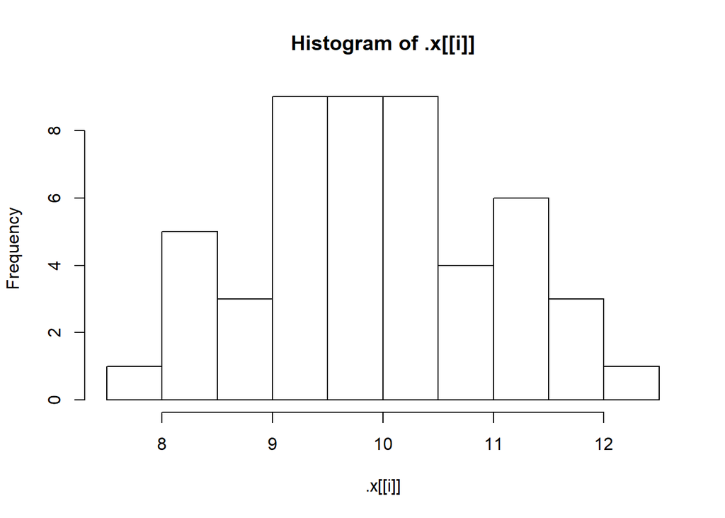

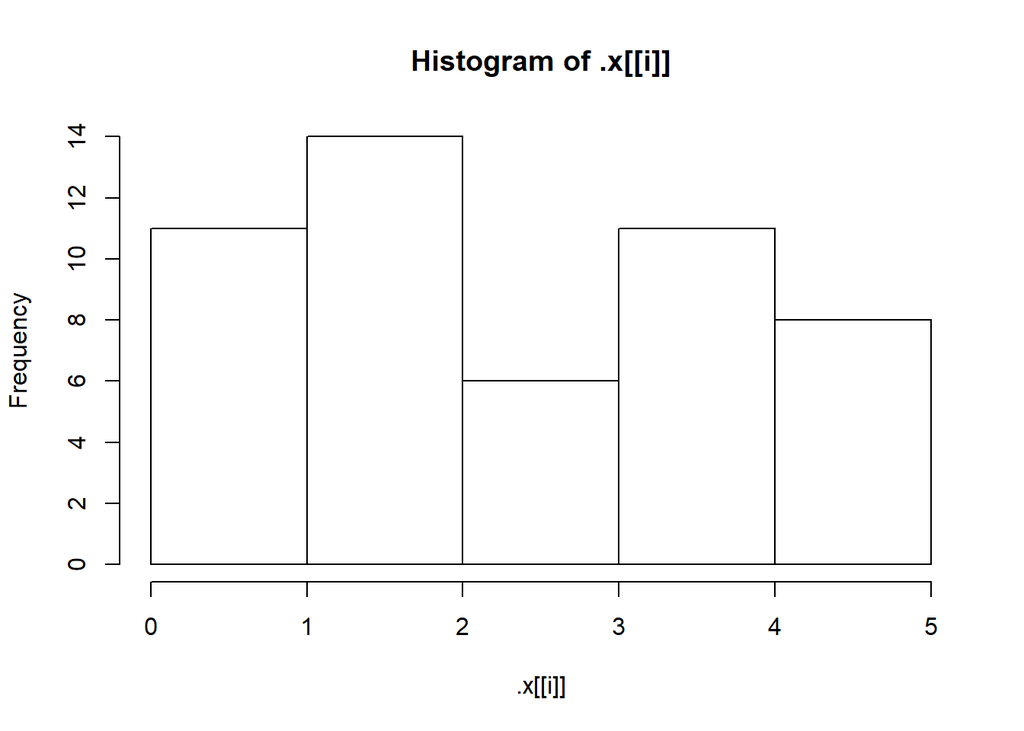

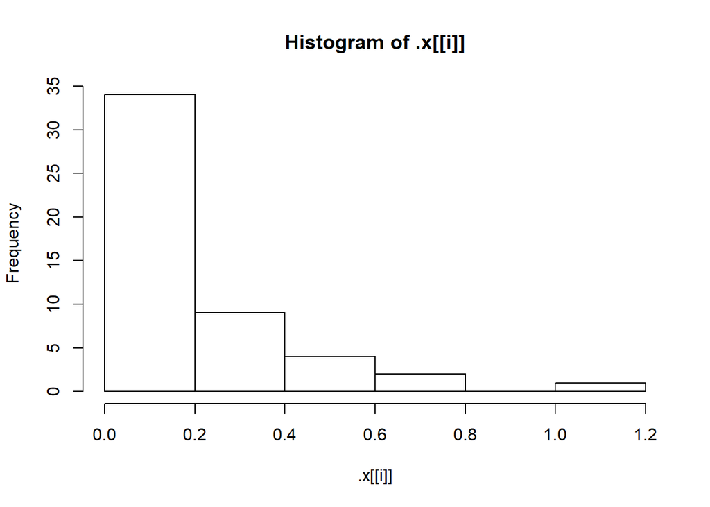

```r
# Define list of functions
funs <- list(Normal = "rnorm", Uniform = "runif", Exp = "rexp")

# Define params
params <- list(
  Normal = list(mean = 10),
  Uniform = list(min = 0, max = 5),
  Exp = list(rate = 5)
)

# Assign the simulated samples to sims
sims <- invoke_map(funs, params, n = 50)

# Use walk() to make a histogram of each element in sims
walk(sims, hist)
```

- Use walk2() to vary two arguments

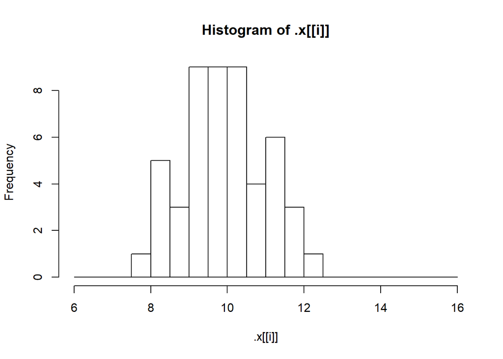

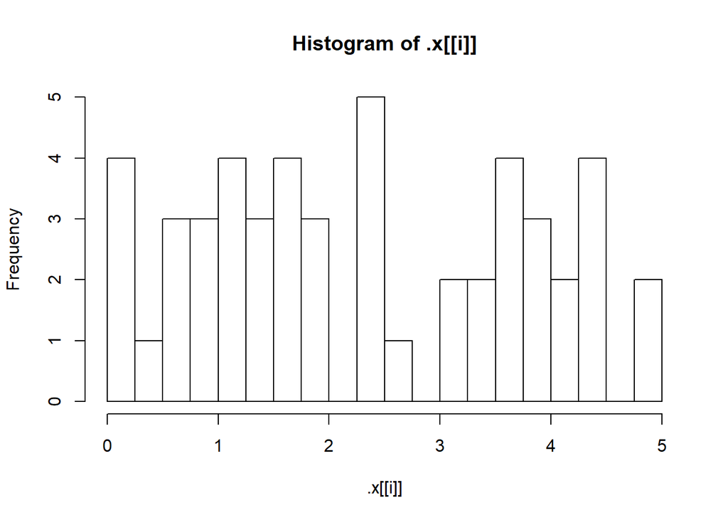

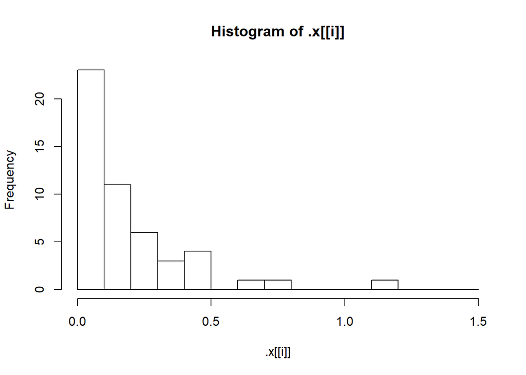

```r
# Reasonable breaks for each sample
breaks_list <- list(
  Normal = seq(6, 16, 0.5),
  Uniform = seq(0,5, 0.25),
  Exp = seq(0, 1.5, 0.1)
)

# Use walk2() to make histograms with the right breaks
walk2(sims, breaks_list, hist)
```

```r
# find_breaks()
find_breaks <- function(x){
  rng <- range(x, na.rm = TRUE)
  seq(rng[1], rng[2], length.out = 30)
}

# Call find_breaks() on sims[[1]]
find_breaks(sims[[1]])
```

```
##  [1]  7.753070  7.901049  8.049029  8.197008  8.344987  8.492966  8.640945
##  [8]  8.788925  8.936904  9.084883  9.232862  9.380841  9.528821  9.676800
## [15]  9.824779  9.972758 10.120737 10.268716 10.416696 10.564675 10.712654
## [22] 10.860633 11.008612 11.156592 11.304571 11.452550 11.600529 11.748508
## [29] 11.896488 12.044467
```

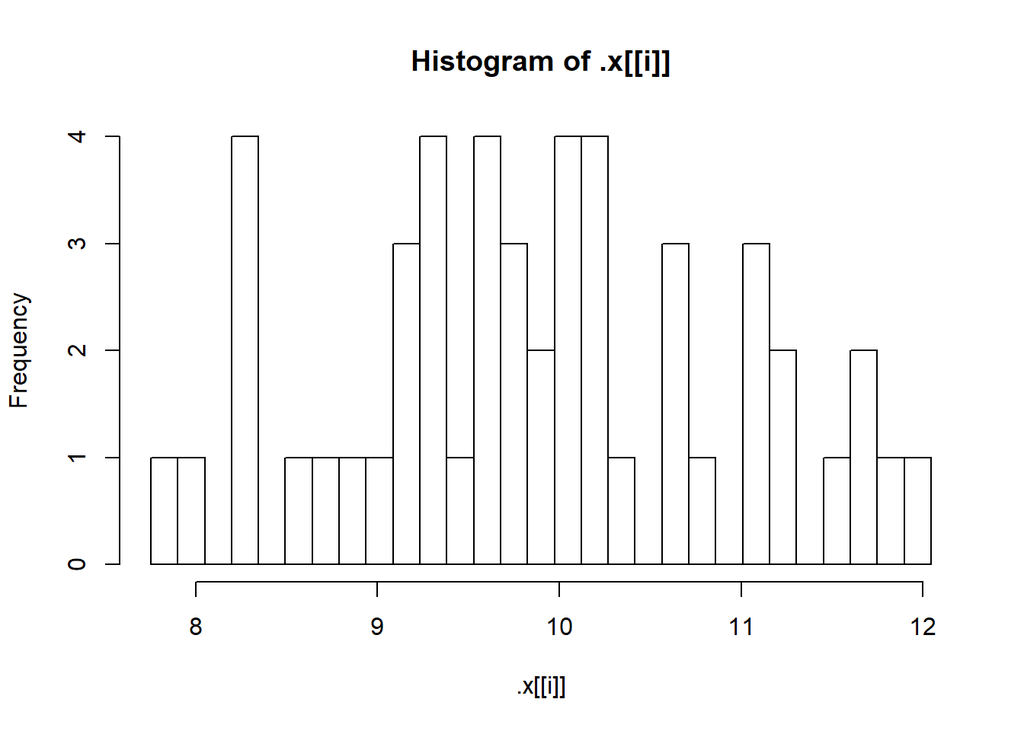

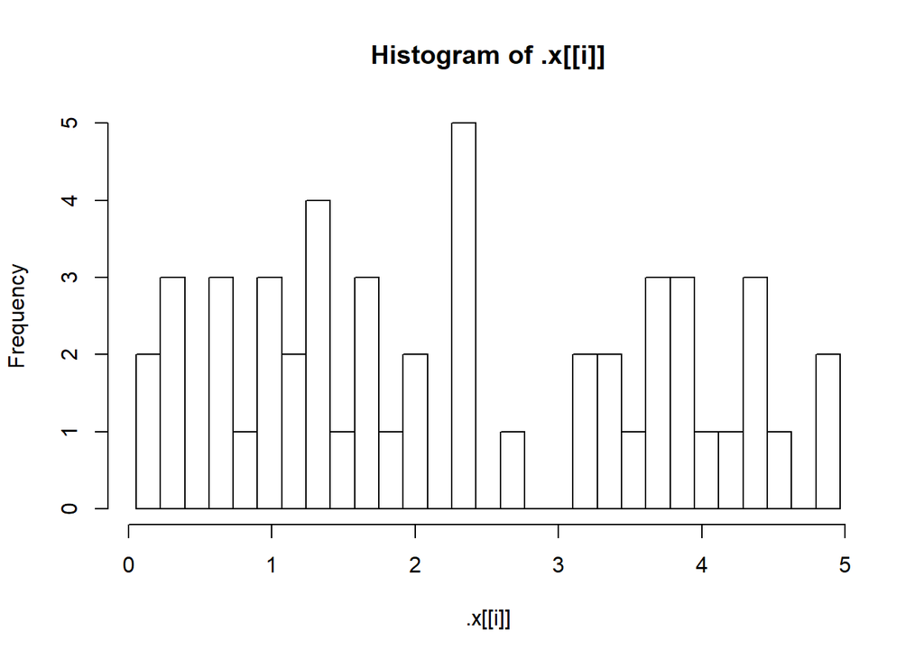

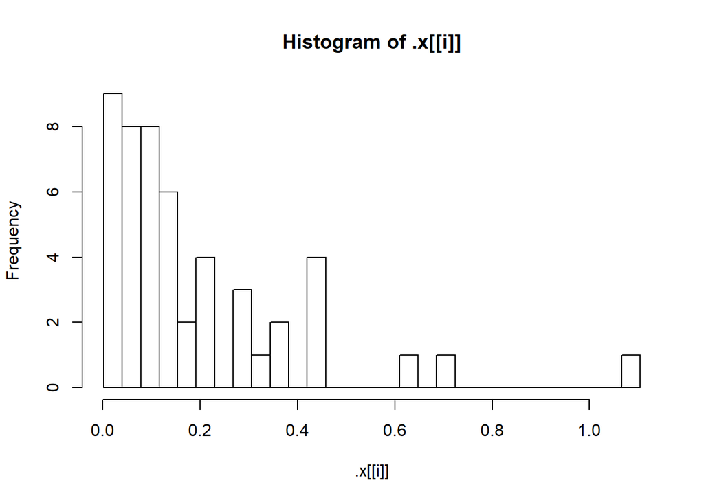

```r
# Use map() to iterate find_breaks() over sims
nice_breaks <- map(sims, find_breaks)

# Use nice_breaks as the second argument to walk2()
walk2(sims, nice_breaks, hist)
```

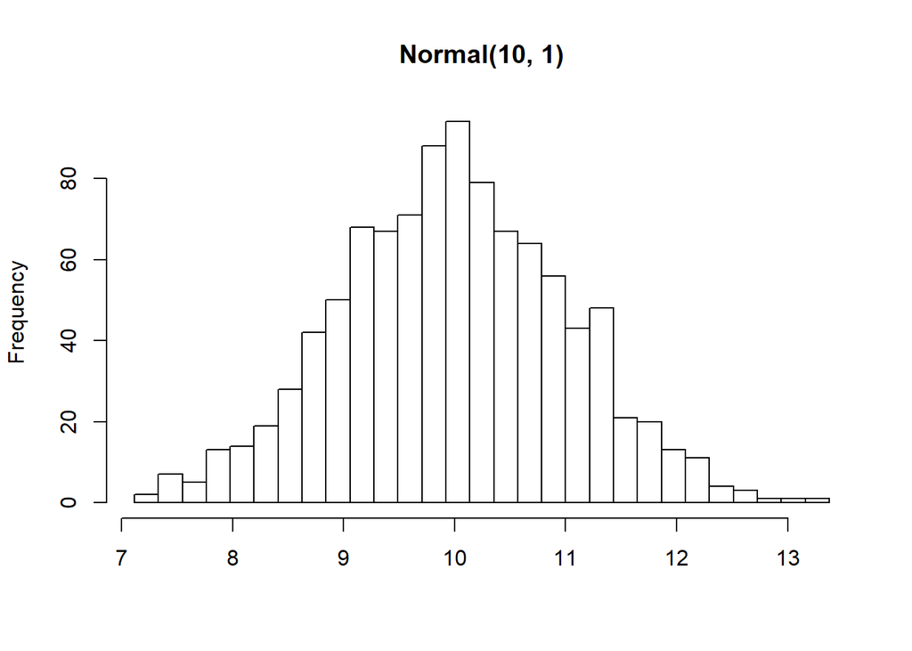

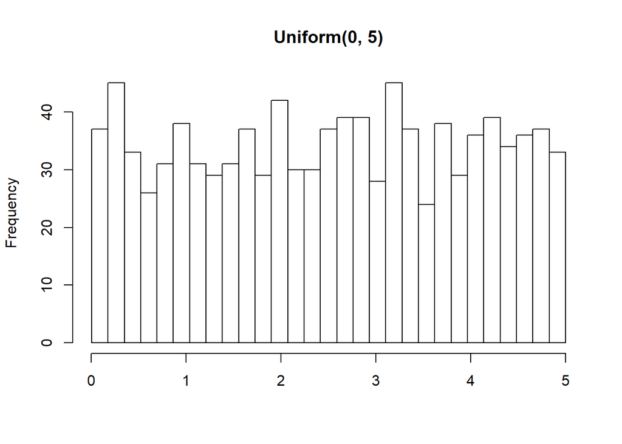

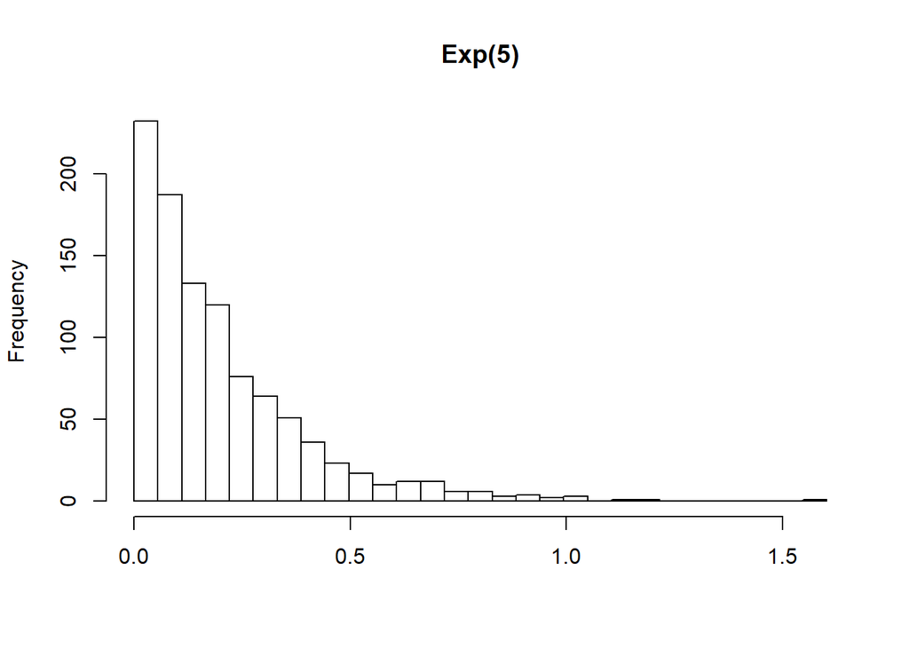

```r
# Increase sample size to 1000
sims <- invoke_map(funs, params, n = 1000)

# Compute nice_breaks (don't change this)
nice_breaks <- map(sims, find_breaks)

# Create a vector nice_titles
nice_titles <- c("Normal(10, 1)", "Uniform(0, 5)", "Exp(5)")

# Use pwalk() instead of walk2()
pwalk(.l = list(x=sims, breaks = nice_breaks, main=nice_titles), .f=hist, xlab= "")
```

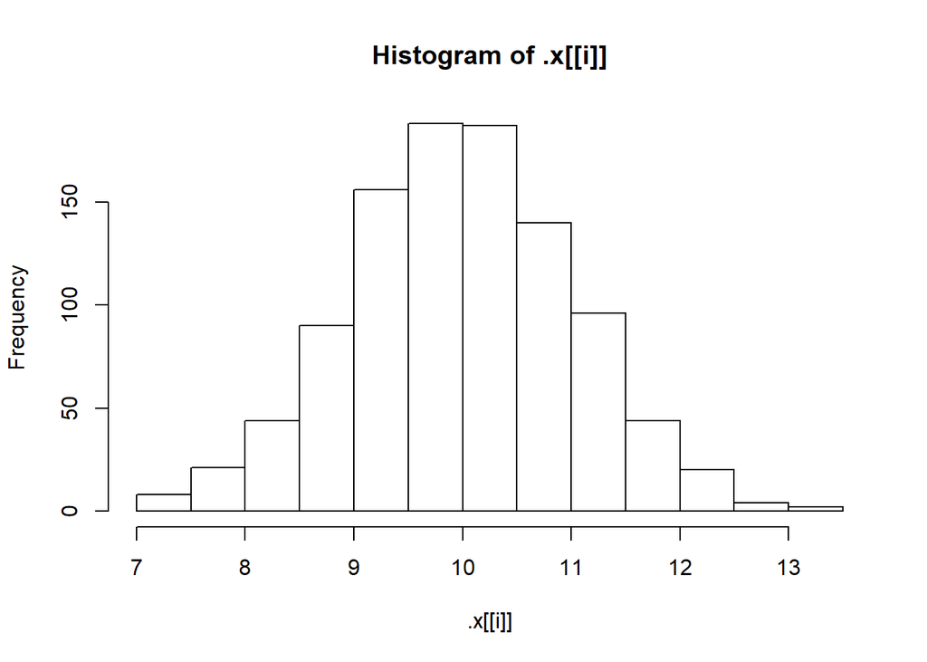

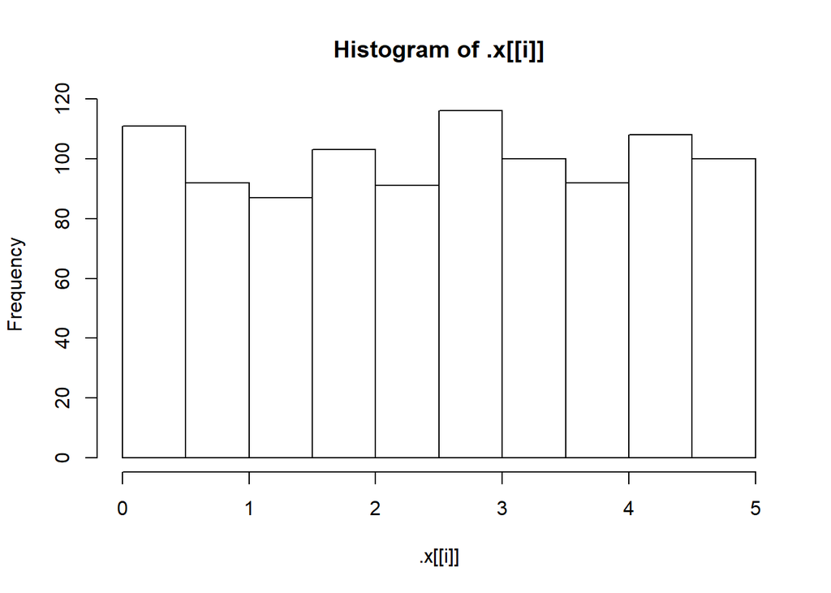

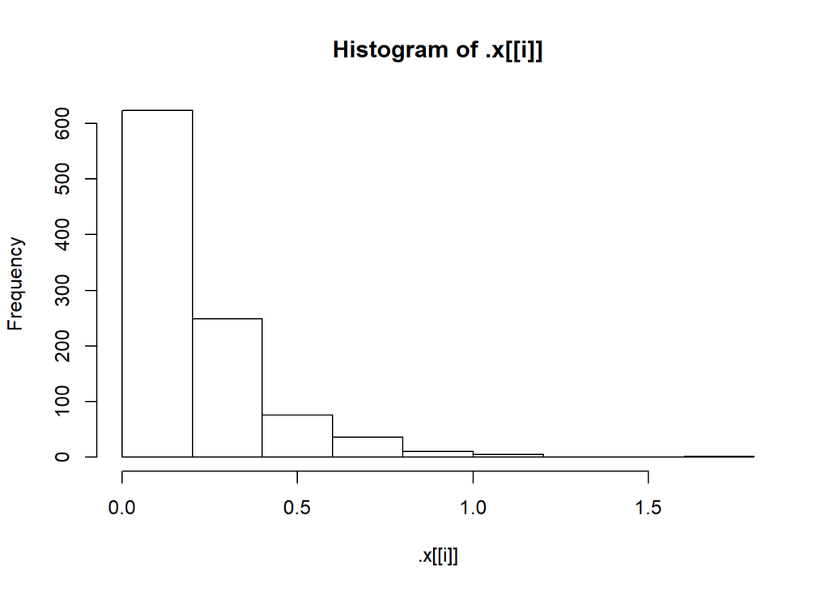

```
## $Normal
##    Min. 1st Qu.  Median    Mean 3rd Qu.    Max.
##   7.114   9.292   9.977   9.986  10.678  13.375
##
## $Uniform
##    Min. 1st Qu.  Median    Mean 3rd Qu.    Max.
## 0.00281 1.29707 2.55605 2.51501 3.77625 4.99769
##
## $Exp
##      Min.   1st Qu.    Median      Mean   3rd Qu.      Max.
## 0.0000228 0.0620172 0.1433989 0.1995064 0.2779681 1.6015886
```

```r
# Pipe this along to map(), using summary() as .f
sims %>%
  walk(hist) %>%
  map(summary)
```

# Robust Functions

Easy to use and reliable functions.

Three main problems:

- Type-unstable functions
- Non-standard evaluation
- Hidden arguments

Throwing errors:

- `stopifnot(is.character(x))`: Check if right arguments
- Using `stop()` with if condition

```r
if (condition) {
  stop("Error", call. = FALSE)
}

# example
if (!is.character(x)){
  stop("`x` should be a character vector", call. = FALSE)
}
```

```r
# Define troublesome x and y
x <- c(NA, NA, NA)
y <- c( 1, NA, NA, NA)

both_na <- function(x, y) {
  # Add stopifnot() to check length of x and y
  stopifnot( length(x) == length(y) )
  sum(is.na(x) & is.na(y))
}

# Call both_na() on x and y
both_na(x, y)
```

Using `stop()` instead of `stopifnot()` allows to specify a more informative error message.

```r
# alternative both_na function
both_na <- function(x, y) {
  # Replace condition with logical
  if ( !(length(x) == length(y)) ) {
    # Replace "Error" with better message
    stop("x and y must have the same length", call. = FALSE)
  }

  sum(is.na(x) & is.na(y))
}

# Call both_na()
both_na(x, y)
```

### Unstable types

- type-inconsistent: type of the return object depends on the input
- surprises occur when you’ve used a type-inconsistent function inside your own function
- sometimes lead to hard to decipher error messages

```r
# example
df[1,]
```

```
##           a        b         c      d
## 1 0.9364474 2.115807 0.4265558 0.9541
```

In general, this should return the first row of the dataframe. But if `df` has only one col, then it returns a vector. Hence, sometimes it returns a `data.frame` and sometimes a `vector`.

Problems occur, when such a behavior is not detected (i.e. within functions).

Note that `[` is a common source of surprises.

Two common solutions for [:

- Use `drop = FALSE:df[x, , drop = FALSE]`
- subset the data frame like a list: `df[x]`

Own functions should be written type-stable to avoid such problems.

- Be aware of type-unstable functions (`[, sapply,...`).
- Avoid using type-inconsistent functions inside your own functions.
- Building a vocabulary of type-consistent functions may help.

```r
df <- data.frame(
  a = 1L,
  b = 1.5,
  y = Sys.time(),
  z = ordered(1)
)

A <- sapply(df[1:4], class)
B <- sapply(df[3:4], class)
```

In this case, A is a list and B a matrix. We will now substitute sapply with `map()` which always returns a list or …

```r
# sapply calls
A <- sapply(df[1:4], class)
B <- sapply(df[3:4], class)
C <- sapply(df[1:2], class)

# Demonstrate type inconsistency
str(A)
```

```
## List of 4
##  $ a: chr "integer"
##  $ b: chr "numeric"
##  $ y: chr [1:2] "POSIXct" "POSIXt"
##  $ z: chr [1:2] "ordered" "factor"
```

```r
str(B)
```

```
##  chr [1:2, 1:2] "POSIXct" "POSIXt" "ordered" "factor"
##  - attr(*, "dimnames")=List of 2
##   ..$ : NULL
##   ..$ : chr [1:2] "y" "z"
```

```r
str(C)
```

```
##  Named chr [1:2] "integer" "numeric"
##  - attr(*, "names")= chr [1:2] "a" "b"
```

```r
# Use map() to define X, Y and Z
X <- map(df[1:4], class)
Y <- map(df[3:4], class)
Z <- map(df[1:2], class)

# Use str() to check type consistency
str(X)
```

```
## List of 4
##  $ a: chr "integer"
##  $ b: chr "numeric"
##  $ y: chr [1:2] "POSIXct" "POSIXt"
##  $ z: chr [1:2] "ordered" "factor"
```

```r
str(Y)
```

```
## List of 2
##  $ y: chr [1:2] "POSIXct" "POSIXt"
##  $ z: chr [1:2] "ordered" "factor"
```

```r
str(Z)
```

```
## List of 2
##  $ a: chr "integer"
##  $ b: chr "numeric"
```

```r
# type-consistent solution
col_classes <- function(df) {
  class_list <- map(df, class)
  map_chr(class_list, 1)
}

# Check that our new function is type consistent
df %>% col_classes() %>% str()
```

```
##  Named chr [1:4] "integer" "numeric" "POSIXct" "ordered"
##  - attr(*, "names")= chr [1:4] "a" "b" "y" "z"
```

```r
df[3:4] %>% col_classes() %>% str()
```

```
##  Named chr [1:2] "POSIXct" "ordered"
##  - attr(*, "names")= chr [1:2] "y" "z"
```

```r
df[1:2] %>% col_classes() %>% str()
```

```
##  Named chr [1:2] "integer" "numeric"
##  - attr(*, "names")= chr [1:2] "a" "b"
```

Alternatively, fail early if something goes wrong

```r
col_classes <- function(df) {
  class_list <- map(df, class)
  # Add a check that no element of class_list has length > 1
  if ( any(map_dbl(class_list, length) > 1) ) {
    stop("Some columns have more than one class", call. = FALSE)
  }
  # Use flatten_chr() to return a character vector
  flatten_chr(class_list)
}

# Check that our new function is type consistent
df %>% col_classes() %>% str()
df[3:4] %>% col_classes() %>% str()
df[1:2] %>% col_classes() %>% str()
```

### Non-standard evaluation

Source of surprises are functions which don’t use the usual lookup rules for variables. Examples are

- `subset()`
- `filter()`

They save a lot of typing but sometimes are acting in a unforeseen way, when used within other functions. Either avoid using non-standard evaluation functions inside your funcitons or learn the surprising cases and protect against them.

```r
library(dplyr)
big_x <- function(df, threshold) {
  dplyr::filter(df, x > threshold)
}

head(big_x(diamonds, 7))
```

```
## # A tibble: 6 x 10
##   carat cut     color clarity depth table price     x     y     z
##   <dbl> <ord>   <ord> <ord>   <dbl> <dbl> <int> <dbl> <dbl> <dbl>
## 1  1.27 Premium H     SI2      59.3    61  2845  7.12  7.05  4.2
## 2  1.5  Fair    H     I1       65.6    54  2964  7.26  7.09  4.7
## 3  1.52 Good    E     I1       57.3    58  3105  7.53  7.42  4.28
## 4  1.52 Good    E     I1       57.3    58  3105  7.53  7.42  4.28
## 5  1.21 Good    E     I1       57.2    62  3144  7.01  6.95  3.99
## 6  1.5  Good    G     I1       57.4    62  3179  7.56  7.39  4.29
```

Hadley’s vignette on [non-standard evaluation](http://rpubs.com/hadley/157957).

We want the following in our next function:

- dataframe must contain variable x
- dataframe must not contain variable threshold

```r
big_x <- function(df, threshold) {
  # Write a check for x not being in df
  if ( !any("x" == colnames(df)) ){
    stop("df must contain variable called x", .call = FALSE)
  }
  # Write a check for threshold being in df
  if (any("threshold" == colnames(df))){
    stop("df must not contain variable called threshold")
  }
  dplyr::filter(df, x > threshold)
}
```

### Hidden arguments

1. Their output only depends on their inputs
2. They don’t affect the outside world except through their return value.
- Hidden arguments are funtion inputs that may be different for different users or sessions
- common example: arguments defaults that depend on global options

```r
# viewing global options
head(options(), 3)
```

```
## $add.smooth
## [1] TRUE
##
## $browserNLdisabled
## [1] FALSE
##
## $CBoundsCheck
## [1] FALSE
```

```r
# specific global options
getOption("digits")
```

```
## [1] 7
```

```r
# change to 5
options(digits = 5)
getOption("digits")
```

```
## [1] 5
```

```r
# change back to default
options(digits = 7)
getOption("digits")
```

```
## [1] 7
```

- Return value of a function should never depend on a global option
- Side effects however may be controlled by global options

```r
# This is the default behavior
options(stringsAsFactors = TRUE)

# load pools
pools <- read.csv("https://assets.datacamp.com/production/repositories/182/datasets/0badb39b50c7daf000698efbca476716db7c1a6f/swimming_pools.csv")

# Examine the structure of pools
str(pools)
```

```
## 'data.frame':    20 obs. of  4 variables:
##  $ Name     : Factor w/ 20 levels "Acacia Ridge Leisure Centre",..: 1 2 3 4 5 6 19 7 8 9 ...
##  $ Address  : Factor w/ 20 levels "1 Fairlead Crescent, Manly",..: 5 20 18 10 9 11 6 15 12 17 ...
##  $ Latitude : num  -27.6 -27.6 -27.6 -27.5 -27.4 ...
##  $ Longitude: num  153 153 153 153 153 ...
```

```r
# Change the global stringsAsFactors option to FALSE
options(stringsAsFactors = FALSE)

# load pools again
pools2 <- read.csv("https://assets.datacamp.com/production/repositories/182/datasets/0badb39b50c7daf000698efbca476716db7c1a6f/swimming_pools.csv")

# Examine the structure of pools2
str(pools2)
```

```
## 'data.frame':    20 obs. of  4 variables:
##  $ Name     : chr  "Acacia Ridge Leisure Centre" "Bellbowrie Pool" "Carole Park" "Centenary Pool (inner City)" ...
##  $ Address  : chr  "1391 Beaudesert Road, Acacia Ridge" "Sugarwood Street, Bellbowrie" "Cnr Boundary Road and Waterford Road Wacol" "400 Gregory Terrace, Spring Hill" ...
##  $ Latitude : num  -27.6 -27.6 -27.6 -27.5 -27.4 ...
##  $ Longitude: num  153 153 153 153 153 ...
```

```r
# restore default
options(stringsAsFactors = TRUE)
```

Wrap up:

**Writing functions:**

- If you have copy-and-pasted two times, it’s time to write a function
- Solve the simple problem outside, before writing the function
- A good function is both correct and understandable

**Functional Programming**

- Use functions that write the correct for loops for you. Abstract away the pattern, so you can focus on the data and actions
- Solve iteration problems more easily and have more understandable code.

**Unusual Inputs and Outputs:**

- Deal with failure using `safely()`
- Iterate over two or more arguments
- Iterate funcitons for their side effects

**Write functions taht don’t suprise**

- Use stop() and stopifnot() to fail early
- Avoid using type-inconsistent functions in your own functions
- Avoid non-standard evaluation functions in your own functions
- Never rely on global options for computational details

However, focus on solving the problme that you’re working on and never feel bad about using a for loop. Get a funciton that works right, for the easiest 80% of the problem. In time, you’ll learn how to get to 99% wiht minimal extra effort. Concise and elegant code is something to strive towards!